# MSstatsQC: longitudinal system suitability monitoring and quality control for proteomic experiments

# Setting options

## Chosing metrics

Metrics (e.g. retention time and peak area) and peptides are chosen within all core functions with ‘metric’ argument. MSstatsQC can handle any metrics of interest. User needs to create data columns just after `Annotations` to import metrics into `MSstatsQC` successfully.

### Example

```r
#Defining metric of interest within APlotFunction
APlotFunction(S9Site54, "LVNELTEFAK", metric = "TotalArea")
APlotFunction(S9Site54, "LVNELTEFAK", metric = "RetentionTime")
```

## Defining mean and variability of a metric

#### Setting predefined limits

Predefined limits are commonly used in system sutiability studies. If the mean and variability of a metric is well known, they can be defined using ‘selectMean’ and ‘selectSD’ arguments in core plot functions (e.g. XmRplots function). For example, if mean of retention time is 34.5 minutes, standard deviation is 1 minutes and X chart is used for peptide LVNELTEFAK, we use XmRplot function as follows.

### Example

```r
#Mean and standard deviation of LVNELTEFAK is known
APlotFunction(data, "LVNELTEFAK", metric = "RetentionTime", selectMean = 34.5, selectSD = 1 )
```

Similarly, if the mean and standard deviation is known, summary functions uses `listMean` and `listSD` arguments. For example, if user monitors retention time and peak assymetry and mean and standard deviations of these metrics are known, arguments will require entering a vector for means and another vector for standard deviations.

### Example

```r
# Retention time >> mean is 34.5 and standard deviation is 1.0
# Peak assymetry >> mean is 1.0  and standard deviation is 0.01
ASummaryFunction(data, listMean=list("Retention time” = 34.5, “Peak asymmetry” = 1.0), listSD = list("Retention time” = 1, “Peak asymmetry” = 0.01))
```

#### Choosing a guide set

The true values of mean and variability of a metric is typically unknown, and their estimates are obtained from a guide set of high quality runs. Generally, a data gathering and parameter estimation step is required. Within that phase, control limits are obtained to test the hypothesis of statistical control. These thresholds are selected to ensure a specified type I error probability (e.g. 0.0027). Constructing control charts and real time evaluation are considered after achieving this phase. Guide sets are defined with ‘L’ and ‘U’ arguments. For example, if retention time of a peptide is monitored and first 20 observations of the dataset are used as a guide set, a plot is constructed as follows.

### Example

```r
#Guide set is chosen as the first 20 observations of dataset
APlotFunction(data, "peptide", metric = "QC metric", L=1, U=20)
```

Guide sets are also required for summary functions when the mean and standard deviation of a metric is not known.

### Example

```r
#Guide set is chosen as the first 20 observations of dataset
ASummaryFunction(data, L=1, U=20)
```

### Tip for Shiny users:

“Options” tab is used to set metrics and peptides of interest. Guide set and known mean and standard deviation are also set within “Options” tab.Select a proper and representative guide set using `Options` tab. The lower bound of guide set indicates the index of the first time point to be included in the guide set. For example, if you choose “1” as a lower bound, it means that first time point will be the first element of the guide set. Similarly, upper bound of guide set shows the index for the last observation. It is possible to use different guide sets for different metrics and peptides.

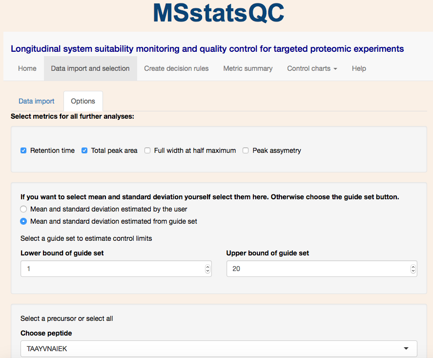

# `MSstatsQC` functions: control charts

These fuctions are used to generate individual (X) and moving range (mR), and cumulative sum for mean (CUSUMm) and cumulative sum for variability (CUSUMv) control charts for each metric. X and mR charts are constructed using `XmRPlots()` function. For example, if user constructs an X control chart of retention time for LVNELTEFAK and retention time mean and standard deviations are present, the function is used as follows.

### Example:

```r
# Retention time >> mean is 34.5 and standard deviation is 1.0
XmRPlots(S9Site54, "LVNELTEFAK", metric = "RetentionTime", type="mean", selectMean = 34.5, selectSD = 1)
```

If user constructs an X control chart of retention time and peak area for LVNELTEFAK and means and standard deviations are not known, the function is used as follows.

### Example:

```r
# Retention time >> first 20 observations are used as a guide set
XmRPlots(S9Site54, "LVNELTEFAK", metric = "RetentionTime", type="mean", L = 1, U = 20)
XmRPlots(S9Site54, "LVNELTEFAK", metric = "TotalPeakArea", type="mean", L = 1, U = 20)
```

If user constructs an mR control chart of retention time and peak area for LVNELTEFAK and mean and standard deviations are not known, the function is used as follows.

### Example:

```r
# Retention time >> first 20 observations are used as a guide set
XmRPlots(S9Site54, "LVNELTEFAK", metric = "RetentionTime", type="dispersion", L = 1, U = 20)
XmRPlots(S9Site54, "LVNELTEFAK", metric = "TotalPeakArea", type="dispersion", L = 1, U = 20)
```

Similarly, if user constructs a CUSUMm or a CUSUMv control chart of retention time and peak area for LVNELTEFAK and mean and standard deviations are not known, `CUSUMPlots` function is used as follows.

```r
# Retention time >> first 20 observations are used as a guide set
CUSUMPlots(S9Site54, "LVNELTEFAK", metric = "RetentionTime", type="mean", L=1, U=20, ytitle="CUSUMm")
CUSUMPlots(S9Site54, "LVNELTEFAK", metric = "TotalPeakArea", type="mean", L=1, U=20, ytitle="CUSUMm")
CUSUMPlots(S9Site54, "LVNELTEFAK", metric = "RetentionTime", type="dispersion", L=1, U=20, ytitle="CUSUMv")
CUSUMPlots(S9Site54, "LVNELTEFAK", metric = "TotalPeakArea", type="dispersion", L=1, U=20, ytitle="CUSUMv")
```

### Tip for Shiny users:

“Control charts” tab is used to construct X and mR and CUSUMm and CUSUMv control charts.

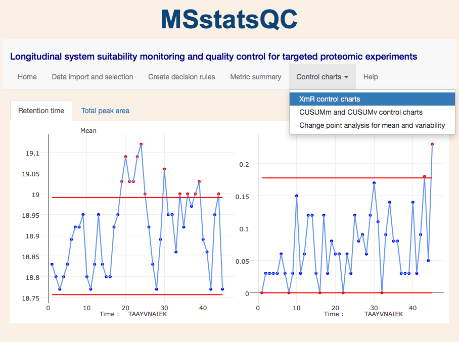

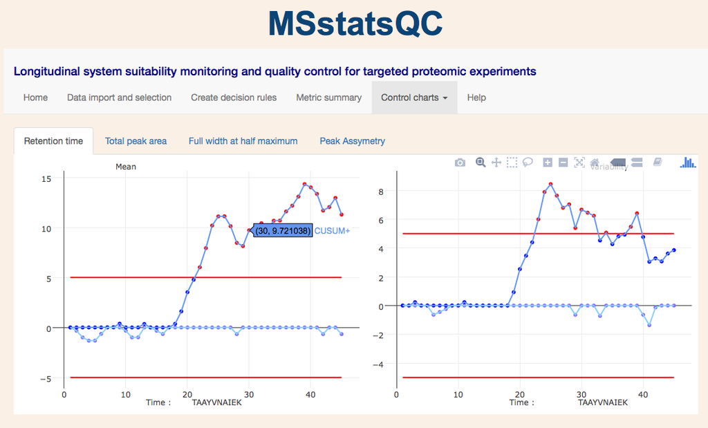

## Change Point Analysis

Follow-up change point analysis is helpful to identify the time of a change for each peptide and metric. `ChangePointEstimator()` function is used for the analysis. This function is one of the core functions and uses the same arguments. We recommend using this function after control charts generate an out-of-control observation. For example, retention time of TAAYVNAIEK increases over time as CUSUMm statistics increases steadily after the 20th time point. User can follow-up with `ChangePointEstimator()` function to find the exact time of retention time drift.

### Example

```r
# Retention time >> first 20 observations are used as a guide set
XmRPlots(S9Site54, "TAAYVNAIEK", metric = "RetentionTime", type="mean", L = 1, U = 20)
ChangePointEstimator(S9Site54, "TAAYVNAIEK", metric = "RetentionTime", type="mean", L = 1, U = 20)
```

We don’t recommend using this function when all the observations are within control limits. In the case of retention time monitoring of LVNELTEFAK, there is no need to further analyse change point.

The time of a variability change can be analyzed with the same fucntion. For example, retention time of YSTDVSVDEVK experiences a drift in the mean of retention time and variability of retention time increases simultaneously. In this case, `ChangePointEstimator()` can be used to identify exact times of both changes.

### Example

```r
# Retention time >> first 20 observations are used as a guide set
XmRPlots(S9Site54, "YSTDVSVDEVK", metric = "RetentionTime", type="mean", L = 1, U = 20)
ChangePointEstimator(S9Site54, "YSTDVSVDEVK", metric = "RetentionTime", type="dispersion", L = 1, U = 20)
```

### Tip for Shiny users:

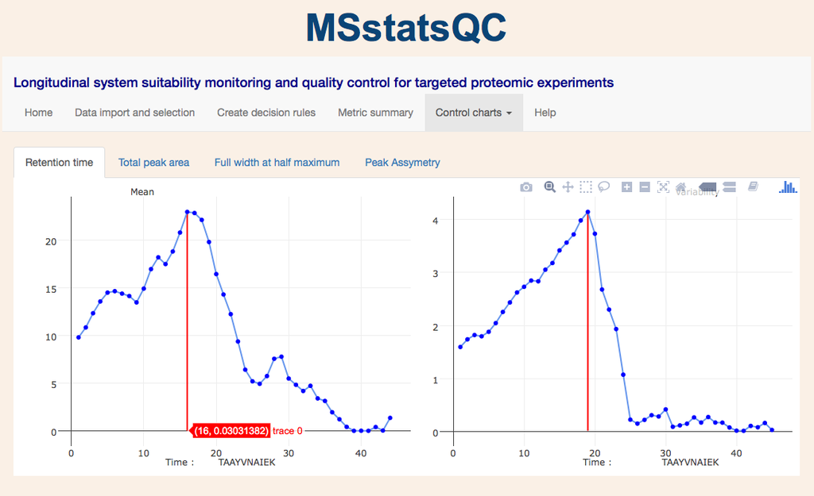

# `MSstatsQC` functions: river and radar plots

`XmRRiverPlots()` and `XmRRadarPlots()` functions are the summary functions used in `MSstatsQC`. They are used to aggregate results over all analytes for X and mR charts. For example, if user would like to aggregate the information gathered from the X charts of retention time for all analytes, upper panel of `XmRRiverPlots()` show for the increases and decreases in retention time. Next, `XmRRadarPlots()` are used to find out which peptides are affected by the problem.

### Example

```r
# Retention time >> first 20 observations are used as a guide set
XmRRiverPlots(S9Site54, L=1, U=20)
XmRRadarPlots(S9Site54, L=1, U=20)
```

`CUSUMRiverPlots()` and `CUSUMRadarPlots()` functions are the summary functions used in `MSstatsQC`. They are used to aggregate results over all analytes for CUSUMm and CUSUMv charts. For example, if user would like to aggregate the information gathered from the CUSUMm charts of retention time for all analytes, upper panel of `CUSUMRiverPlots()` show for the increases and decreases in retention time. Next, `CUSUMRadarPlots()` are used to find out which peptides are affected by the problem.

### Example

```r
# Retention time >> first 20 observations are used as a guide set
CUSUMRiverPlots(S9Site54, L=1, U=20)
CUSUMRadarPlots(S9Site54, L=1, U=20)
```

### Tip for Shiny users:

Summary plots are available in the `Metric summary` tab under `Detailed performance: plot summaries`.

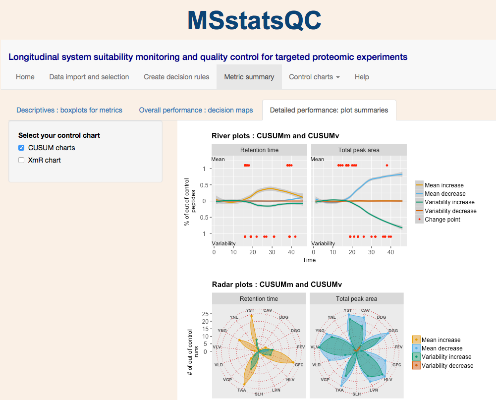

# `MSstatsQC` functions: decision map

`DecisionMap()` functions another summary function used in `MSstatsQC`. It is used to compare aggregated results over all analytes for a certain method such as XmR charts with the user defined criteria. Firstly, user defines the performance criteria and run `DecisionMap()` function to visualize overall performance. This function uses all the arguments of summary plots listed previously. Additionally, the following arguments are used

### Arguments

- `method`: the name of the method prefered. It is either “CUSUM” or “XmR”` interest.
- `peptideThresholdRed`: a threshold that marks percentage of out-of-control peptides. if the percentage is above this threshold, the color is red meaning fail. Default is 0.7.
- `peptideThresholdYellow`: a threshold that marks percentage of out-of-control peptides. if the percentage within this threshold and `peptideThresholdRed`, the color is yellow meaning warning. Default is 0.5.

### Example

```r
# A decision map for Site 54 can be generated using the following script
# Retention time >> first 20 observations are used as a guide set
DecisionMap(S9Site54,method="XmR",peptideThresholdRed = 0.25,peptideThresholdYellow = 0.10,
                          L = 1,U = 20,type = "mean",title = "Decision map",listMean = NULL,listSD = NULL)
```

### Tip for Shiny users:

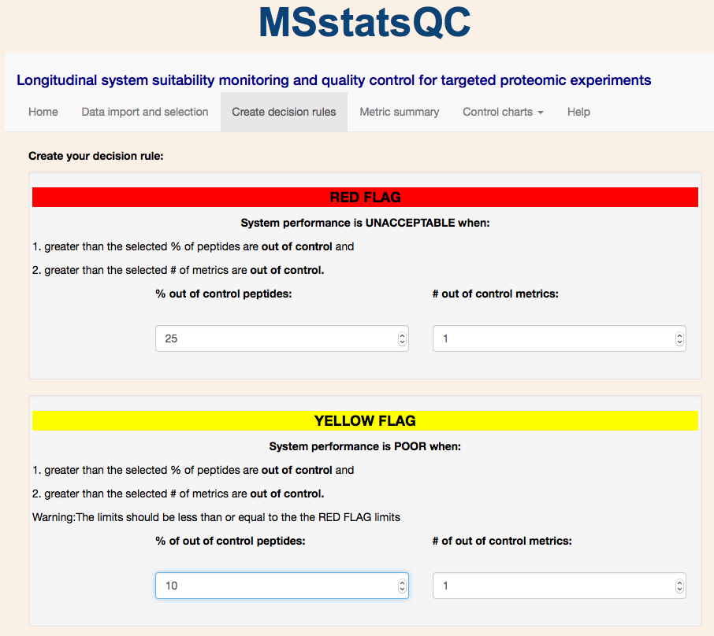

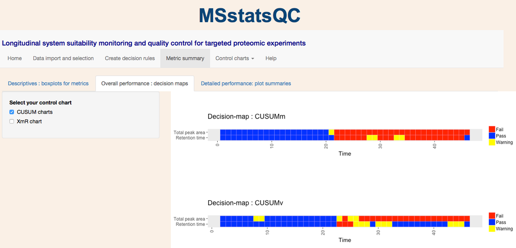

The `MSstatsQC` workflow is also summarized in a cheatsheet that is available at www.msstats.org/msstatsqc. Please refer to the cheatsheet for further information.